# SDM Assignment

## 🐜 The Argentine ant

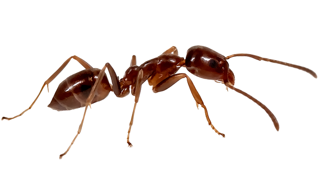

[The GitHub repository](https://github.com/clarkevansteenderen/Hons_SDM/tree/main) for this module contains a folder called **SDM_assignment**, which contains the R scripts needed. Download the required data for this assignment from [Google Drive](https://drive.google.com/drive/folders/1JXmjOVD9QxfNadFVna6n6dLdg5I8rvG7), unzip the folder, and place it in the same folder as your R project for this assignment.

The R script, `SDM_assignment/argentine_ant_exercise.R`, contains the code to run a MaxEnt SDM on the **full distribution** of the Argentine ant, *Linepithema humile* (Mayr; Hymenoptera: Formicidae). The presence and background points are already provided for you in the associated `data/` folder, along with the optimal climate variables after multicollinearity testing. The presence records for the ant have been grouped into its (1) native South American range, and the invaded regions of (2) South Africa, (3) Europe, (4) Australia, and (5) New Zealand.

Run through the provided code, and make sure that you can reproduce the MaxEnt model trained on the ant’s **full distribution**, and generate the prediction maps for each of the five ranges. Look at the model tuning results to confirm what the model performance metrics were.

Now it’s your turn to do some coding, and train MaxEnt models. Use the example code provided to guide you, and feel free to ask for help if you get stuck!

Your final submission should be a **single zipped folder** that contains:

- Clean **R code** that you used to complete each section below (submit **.R** file(s) only). Please clearly mark sections in your script using comments: `#`. Pick a style!

```r
#################
#QUESTION 1
#################
your.code here

#================
#QUESTION 2
#================
more.code.here

#----------------
#QUESTION 3
#----------------
more.code.here
```

- A **figures/** folder containing all your plots and maps
- A **Word document** containing your summary report. If you are feeling ambitious, you can also do this in an R markdown file (.Rmd), where you can include both text and code blocks that you can run in R within the document itself. Let me know if you would like some help setting this up.

### Assignment Tasks

#### 1. **Train a native range MaxEnt model**

Use the provided presence and background points, `data.native`, for the ant’s **native distribution**, and fit another MaxEnt model using only the **native range** data. Use the same tuned parameters as before:

- `betamultiplier = 3.0`
- `hinge = TRUE`

Save the model to the `model_native` folder.

**[10 marks]**

#### 2. **Get the `dismo` response curves and variable contributions**

- Use `dismo::response(your_native_model)` to extract response curves for the native-range trained model. Save these response curves as a single figure
- Create and save a bar plot of the percentage contribution of each variable to the model’s performance

**[10 marks]**

#### 3. **Re-run the model, where you exclude unimportant variables**

Exclude variables contributing less than 5%, and re-run the model (you can overwrite your old one if you like with this new model).

Tip: use `dplyr::select(YOURDATA, -c(BIO.X, BIO.Y, BIO.Z))` to exclude the predictor variables that you do **not** want:

```r
MODEL = dismo::maxent(
  x = dplyr::select(YOURDATA, -c(wc2.1_2.5m_bio_X, wc2.1_2.5m_bio_Y, wc2.1_2.5m_bio_Z)),
  p = p_vector_native,
  path = here::here("model_native"),
  ...
  ...
)
```

**[10 marks]**

#### 4. **Project the updated model onto each of the five ranges**

Reminder: the ranges we are interested in are (1) native South American range, and the invaded regions of (2) South Africa, (3) Europe, (4) Australia, and (5) New Zealand.

Use the `fit_maxent.R` function like this:

```r
source("fit_maxent.R")
# Example usage for South Africa:
SA.climvars.map.native = fit_maxent_climvars(PARAMETERS)
```

Use the example code provided in the R script to correctly set the PARAMETERS.

**[15 marks]**

#### 5. **Compare full-range vs native-trained models using difference maps**

Threshold maps (for all five regions) at 0.7 suitability (i.e. suitability > 0.7) and subtract the full range from the native range. The code block below gives you an idea of how to do this:

```r
# Threshold native-trained and full-trained maps
SA.NATIVE.thresh0.7 = SA.NATIVE$raster > 0.7
SA.FULL.thresh0.7 = SA.FULL$raster > 0.7

# Compute difference
SA.DIFF = SA.NATIVE.thresh0.7 - SA.FULL.thresh0.7

# Convert to data frame
SA.DIFF.DF = as.data.frame(SA.DIFF, xy= TRUE)
```

Plot using ggplot:

```r
diff.plot = ggplot() +
     geom_raster(data = SA.DIFF.DF, aes(x = x, y = y, fill = value)) +
     scale_fill_gradientn(colors = c("darkred", "grey85", "darkgreen"), na.value = "transparent") +
     theme_minimal() +
     labs(title = "Difference Map: Native vs Full-trained Model")
```

In this context the colours mean:

- **Dark red**: under-prediction by native model
- **Dark green**: over-prediction by native model
- **Grey**: agreement between the models

Example output for South America is shown below:

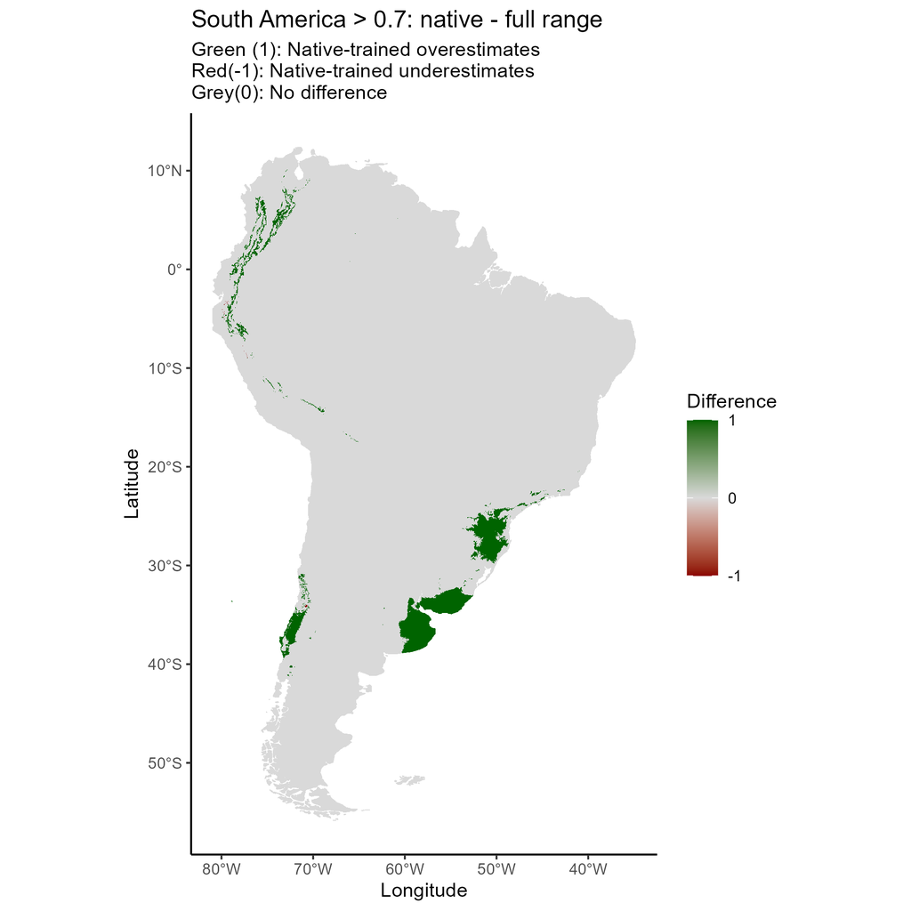

**[15 marks]**

#### **Write a summary report**

In a short report, cover each of the aspects below under its own heading. You do not need to paste all your figures into the document; just make sure that they are all saved as PNGs in your **figures/** folder.

1. Discuss the differences you observed between the two models (full-range vs native range-trained), and what you think contributed to these differences.
2. Discuss what the implications could be of these different modelling approaches for researchers interested in conservation planning and invasive species management.
3. Comment on the full-range trained models for each region, and suggest which areas are the most climatically suitable for the Argentine ant.
4. Discuss any three potential caveats to the models you have created in this assignment.

Your **figures/** folder should contain these figures:

- Response curves for your native-range trained model (Question (Q) 2)
- A bar plot of the percentage contribution of each variable to your model’s performance (Q2)
- A MaxEnt prediction map for each of the five regions based on your **native range-trained model**) (Q4)
- Thresholded difference maps for each of the five regions (i.e. the raster difference between the native and full-range trained models) (Q5)

**[40 marks]**

### General Task

#### 🐜 Task 1 [10 marks]

Create a function that takes in two raster layers (`raster.layer1`, `raster.layer2`) and a threshold value (`thresh`) as parameters. This function should then:

- Threshold each raster layer so that values above that threshold are retained (`raster.layer > thresh`)
- Subtract one raster layer from the other, such that: `raster.layer1 - raster.layer2`
- Convert the result into a data frame
- Create a ggplot with the data frame
- Return the ggplot

This is a reminder of how you can plot a data frame that was extracted from a raster:

```r
diff.plot = ggplot() +
     geom_raster(data = YOUR.DF, aes(x = x, y = y, fill = value)) +
     scale_fill_gradientn(colors = c("darkred", "grey85", "darkgreen"), na.value = "transparent") +
     theme_minimal()
```

Use the rasters from Question 5 to test the function.

### 🏆 Bonus Tasks [20 marks]

#### 🐜 Task 1 [10 marks]

Train another MaxEnt model for the Argentine ant, but this time, create the model using only the **invaded range** data. Project this model back onto the native range (South America), and overlay the presence points onto the map. Comment on how well the model predicted the true native range occurrences.

#### 🐜 Task 2 [10 marks]

Use your full-range trained MaxEnt model for the Argentine ant, but now project that onto South Africa using the future climate raster layers (CMIP6) for the year 2070 under the RCP4.5 and RCP8.5 scenarios. What does the situation look like for 2070 compared to the current climate predictions? Provide the prediction maps for South Africa under the two scenarios, and also create a difference raster where you show the difference between the future and current climate predictions.

**Total: 110 marks (+20 bonus)**